# Computer Assignment 0, Introduction to Artificial Intelligence

#### The purpose of this project is to fill in the gaps of a database by predicting them with the help of statistical analysis

In this project, we are given data on how different users react to an online ad. There is no data on whether the user has clicked on the ad for some users and we need to predict their behavior by analyzing data obtained from other users' choices.

## Part 1

The data used in this section contains information about 1000 users of a site who came across an Internet ad. Each line of this file contains a record of a user that contains this information: daily time spent by the user on the site, user age, average user area revenue, user's daily internet usage, ad subject, user's city of residence, user gender, user's country of residence, when the record was recorded and whether the user Ad clicked or not.

```python
import pandas as pd
input_data = pd.read_csv("advertising_dataset.csv")
input_data
```

|  | Unnamed: 0 | Daily Time Spent on Site | Age | Area Income | Daily Internet Usage | Ad Topic Line | City | Gender | Country | Timestamp | Clicked on Ad |
| --- | --- | --- | --- | --- | --- | --- | --- | --- | --- | --- | --- |
| 0 | 0 | 68.95 | 35.0 | 61833.90 | 256.09 | Cloned 5thgeneration orchestration | Wrightburgh | Female | Tunisia | 2016-03-27 00:53:11 | 0.0 |
| 1 | 1 | 80.23 | 31.0 | 68441.85 | NaN | Monitored national standardization | West Jodi | Male | Nauru | 2016-04-04 01:39:02 | 0.0 |
| 2 | 2 | 69.47 | 26.0 | 59785.94 | 236.50 | Organic bottom-line service-desk | Davidton | Female | San Marino | 2016-03-13 20:35:42 | 0.0 |
| 3 | 3 | 74.15 | 29.0 | 54806.18 | 245.89 | Triple-buffered reciprocal time-frame | West Terrifurt | Male | Italy | 2016-01-10 02:31:19 | 0.0 |
| 4 | 4 | 68.37 | 35.0 | 73889.99 | 225.58 | Robust logistical utilization | South Manuel | Female | Iceland | 2016-06-03 03:36:18 | 0.0 |
| ... | ... | ... | ... | ... | ... | ... | ... | ... | ... | ... | ... |
| 995 | 995 | 72.97 | 30.0 | 71384.57 | 208.58 | Fundamental modular algorithm | Duffystad | Male | Lebanon | 2016-02-11 21:49:00 | 1.0 |
| 996 | 996 | 51.30 | 45.0 | 67782.17 | 134.42 | Grass-roots cohesive monitoring | New Darlene | Male | Bosnia and Herzegovina | 2016-04-22 02:07:01 | 1.0 |
| 997 | 997 | 51.63 | 51.0 | 42415.72 | 120.37 | Expanded intangible solution | South Jessica | Male | Mongolia | 2016-02-01 17:24:57 | 1.0 |
| 998 | 998 | 55.55 | 19.0 | 41920.79 | 187.95 | Proactive bandwidth-monitored policy | West Steven | Female | Guatemala | 2016-03-24 02:35:54 | 0.0 |
| 999 | 999 | NaN | 26.0 | 29875.80 | 178.35 | Virtual 5thgeneration emulation | Ronniemouth | Female | Brazil | 2016-06-03 21:43:21 | 1.0 |

1000 rows × 11 columns

The tail function is used here. This function shows us the last n rows of data. The value of the number n is 5 by default.

```python
input_data.tail(7)
```

|  | Unnamed: 0 | Daily Time Spent on Site | Age | Area Income | Daily Internet Usage | Ad Topic Line | City | Gender | Country | Timestamp | Clicked on Ad |
| --- | --- | --- | --- | --- | --- | --- | --- | --- | --- | --- | --- |
| 993 | 993 | 64.20 | 27.0 | 66200.96 | 227.63 | Phased zero tolerance extranet | Edwardsmouth | Male | Isle of Man | 2016-02-11 23:45:01 | 0.0 |
| 994 | 994 | 43.70 | 28.0 | 63126.96 | 173.01 | Front-line bifurcated ability | Nicholasland | Female | Mayotte | 2016-04-04 03:57:48 | 1.0 |
| 995 | 995 | 72.97 | 30.0 | 71384.57 | 208.58 | Fundamental modular algorithm | Duffystad | Male | Lebanon | 2016-02-11 21:49:00 | 1.0 |
| 996 | 996 | 51.30 | 45.0 | 67782.17 | 134.42 | Grass-roots cohesive monitoring | New Darlene | Male | Bosnia and Herzegovina | 2016-04-22 02:07:01 | 1.0 |
| 997 | 997 | 51.63 | 51.0 | 42415.72 | 120.37 | Expanded intangible solution | South Jessica | Male | Mongolia | 2016-02-01 17:24:57 | 1.0 |
| 998 | 998 | 55.55 | 19.0 | 41920.79 | 187.95 | Proactive bandwidth-monitored policy | West Steven | Female | Guatemala | 2016-03-24 02:35:54 | 0.0 |
| 999 | 999 | NaN | 26.0 | 29875.80 | 178.35 | Virtual 5thgeneration emulation | Ronniemouth | Female | Brazil | 2016-06-03 21:43:21 | 1.0 |

The head function is used here. This function shows us the first n rows of data. The value of the number n is 5 by default.

```python
input_data.head()
```

|  | Unnamed: 0 | Daily Time Spent on Site | Age | Area Income | Daily Internet Usage | Ad Topic Line | City | Gender | Country | Timestamp | Clicked on Ad |
| --- | --- | --- | --- | --- | --- | --- | --- | --- | --- | --- | --- |
| 0 | 0 | 68.95 | 35.0 | 61833.90 | 256.09 | Cloned 5thgeneration orchestration | Wrightburgh | Female | Tunisia | 2016-03-27 00:53:11 | 0.0 |
| 1 | 1 | 80.23 | 31.0 | 68441.85 | NaN | Monitored national standardization | West Jodi | Male | Nauru | 2016-04-04 01:39:02 | 0.0 |
| 2 | 2 | 69.47 | 26.0 | 59785.94 | 236.50 | Organic bottom-line service-desk | Davidton | Female | San Marino | 2016-03-13 20:35:42 | 0.0 |
| 3 | 3 | 74.15 | 29.0 | 54806.18 | 245.89 | Triple-buffered reciprocal time-frame | West Terrifurt | Male | Italy | 2016-01-10 02:31:19 | 0.0 |
| 4 | 4 | 68.37 | 35.0 | 73889.99 | 225.58 | Robust logistical utilization | South Manuel | Female | Iceland | 2016-06-03 03:36:18 | 0.0 |

The describe function is used here. This function shows us descriptive statistics that summarize the central tendency, dispersion and shape of a dataset’s distribution, excluding NaN values.

```python
input_data.describe()
```

|  | Unnamed: 0 | Daily Time Spent on Site | Age | Area Income | Daily Internet Usage | Clicked on Ad |
| --- | --- | --- | --- | --- | --- | --- |
| count | 1000.000000 | 907.000000 | 979.000000 | 1000.000000 | 913.000000 | 832.000000 |
| mean | 499.500000 | 64.794818 | 36.009193 | 55000.000080 | 179.751271 | 0.496394 |
| std | 288.819436 | 15.954841 | 8.783636 | 13414.634022 | 43.957934 | 0.500288 |
| min | 0.000000 | 32.600000 | 19.000000 | 13996.500000 | 104.780000 | 0.000000 |
| 25% | 249.750000 | 50.615000 | 29.000000 | 47031.802500 | 138.550000 | 0.000000 |
| 50% | 499.500000 | 67.940000 | 35.000000 | 57012.300000 | 183.480000 | 0.000000 |
| 75% | 749.250000 | 78.555000 | 42.000000 | 65470.635000 | 217.850000 | 1.000000 |
| max | 999.000000 | 91.430000 | 61.000000 | 79484.800000 | 269.960000 | 1.000000 |

For example, here numerical data is described in terms of number, average, minimum and maximum value, stansard devision and percentilies.

## Part 2

The info function is used here. This function shows us count of non null fields and data type of each columns.

```python
input_data.info()
```

```
<class 'pandas.core.frame.DataFrame'>
RangeIndex: 1000 entries, 0 to 999
Data columns (total 11 columns):
 #   Column                    Non-Null Count  Dtype
---  ------                    --------------  -----
 0   Unnamed: 0                1000 non-null   int64
 1   Daily Time Spent on Site  907 non-null    float64
 2   Age                       979 non-null    float64
 3   Area Income               1000 non-null   float64
 4   Daily Internet Usage      913 non-null    float64
 5   Ad Topic Line             1000 non-null   object
 6   City                      1000 non-null   object
 7   Gender                    1000 non-null   object
 8   Country                   1000 non-null   object
 9   Timestamp                 1000 non-null   object
 10  Clicked on Ad             832 non-null    float64
dtypes: float64(5), int64(1), object(5)
memory usage: 86.1+ KB
```

```python
input_data['Gender'].replace({'Male': 1, 'Female': 0}, inplace=True)
input_data
```

|  | Unnamed: 0 | Daily Time Spent on Site | Age | Area Income | Daily Internet Usage | Ad Topic Line | City | Gender | Country | Timestamp | Clicked on Ad |
| --- | --- | --- | --- | --- | --- | --- | --- | --- | --- | --- | --- |
| 0 | 0 | 68.95 | 35.0 | 61833.90 | 256.09 | Cloned 5thgeneration orchestration | Wrightburgh | 0 | Tunisia | 2016-03-27 00:53:11 | 0.0 |
| 1 | 1 | 80.23 | 31.0 | 68441.85 | NaN | Monitored national standardization | West Jodi | 1 | Nauru | 2016-04-04 01:39:02 | 0.0 |
| 2 | 2 | 69.47 | 26.0 | 59785.94 | 236.50 | Organic bottom-line service-desk | Davidton | 0 | San Marino | 2016-03-13 20:35:42 | 0.0 |
| 3 | 3 | 74.15 | 29.0 | 54806.18 | 245.89 | Triple-buffered reciprocal time-frame | West Terrifurt | 1 | Italy | 2016-01-10 02:31:19 | 0.0 |
| 4 | 4 | 68.37 | 35.0 | 73889.99 | 225.58 | Robust logistical utilization | South Manuel | 0 | Iceland | 2016-06-03 03:36:18 | 0.0 |
| ... | ... | ... | ... | ... | ... | ... | ... | ... | ... | ... | ... |
| 995 | 995 | 72.97 | 30.0 | 71384.57 | 208.58 | Fundamental modular algorithm | Duffystad | 1 | Lebanon | 2016-02-11 21:49:00 | 1.0 |
| 996 | 996 | 51.30 | 45.0 | 67782.17 | 134.42 | Grass-roots cohesive monitoring | New Darlene | 1 | Bosnia and Herzegovina | 2016-04-22 02:07:01 | 1.0 |
| 997 | 997 | 51.63 | 51.0 | 42415.72 | 120.37 | Expanded intangible solution | South Jessica | 1 | Mongolia | 2016-02-01 17:24:57 | 1.0 |
| 998 | 998 | 55.55 | 19.0 | 41920.79 | 187.95 | Proactive bandwidth-monitored policy | West Steven | 0 | Guatemala | 2016-03-24 02:35:54 | 0.0 |
| 999 | 999 | NaN | 26.0 | 29875.80 | 178.35 | Virtual 5thgeneration emulation | Ronniemouth | 0 | Brazil | 2016-06-03 21:43:21 | 1.0 |

1000 rows × 11 columns

## Part 3

Using the following functions, the number of missing data in each column is obtained.

```python
input_data.isnull().sum()
```

```
Unnamed: 0                    0
Daily Time Spent on Site     93
Age                          21
Area Income                   0
Daily Internet Usage         87
Ad Topic Line                 0
City                          0
Gender                        0
Country                       0
Timestamp                     0
Clicked on Ad               168
dtype: int64
```

At the bottom we filled in the missing data cells with the average of the data in the same column.

```python
input_data['Daily Time Spent on Site'].fillna(input_data['Daily Time Spent on Site'].mean(), inplace=True)
input_data['Age'].fillna(input_data['Age'].mean(), inplace=True)
input_data['Daily Internet Usage'].fillna(input_data['Daily Internet Usage'].mean(), inplace=True)

input_data.isnull().sum()
```

```
Unnamed: 0                    0
Daily Time Spent on Site      0
Age                           0
Area Income                   0
Daily Internet Usage          0
Ad Topic Line                 0
City                          0
Gender                        0
Country                       0
Timestamp                     0
Clicked on Ad               168
dtype: int64
```

Another way is to fill in the blanks using the median, which is useful when the data has outliers because outliers affect mean of data a lot.

## Part 4

```python
male_num = len(input_data[input_data['Gender'] == 1])
female_num = len(input_data[input_data['Gender'] == 0])

print("Number of females : \n", female_num, '\n')
print("Number of males : \n", male_num)
```

```
Number of females :
 519

Number of males :
 481
```

```python
click_num = len(input_data[input_data['Clicked on Ad'] == 1])
not_click_num = len(input_data[input_data['Clicked on Ad'] == 0])
print("Number of people who clicked on the ad : \n", click_num, '\n')
print("Number of people who did not click on the ad : \n", not_click_num)
```

```
Number of people who clicked on the ad :
 413

Number of people who did not click on the ad :
 419
```

## Part 5

```python
selected_num = len(input_data[(input_data['Gender'] == 0) & (input_data['Age'] > 21)])
print("Number of women over the age of 21 : \n", selected_num)
```

```
Number of women over the age of 21 :
 514
```

## Part 6

In this section, we first group the data according to the value of 'Clicked on Ad' column with groupby function and then we get the average age of each group.

```python
import time
tic_vectorization = time.time()
mean_data = input_data.groupby(['Clicked on Ad'])['Age'].mean()
toc_vectorization = time.time()
total_vectorization = toc_vectorization - tic_vectorization
print(total_vectorization)
print(mean_data)
```

```
0.0018260478973388672
Clicked on Ad
0.0    31.723326
1.0    40.295600
Name: Age, dtype: float64
```

## Part 7

```python
tic_loop = time.time()
click_count = 0
click_age = 0
not_click_count = 0
not_click_age = 0

for index, record in input_data.iterrows() :
    if record['Clicked on Ad'] == 1:
        click_count = click_count + 1
        click_age = click_age + record['Age']
    elif record['Clicked on Ad'] == 0:
        not_click_count = not_click_count + 1
        not_click_age = not_click_age + record['Age']

toc_loop = time.time()
total_loop = toc_loop - tic_loop
print(total_loop)
print('Clicked on Ad')
print('0.0')
print(not_click_age/not_click_count)
print('1.0')
print(click_age/click_count)
```

```
0.11760210990905762
Clicked on Ad
0.0
31.723325881701896
1.0
40.295599848637366
```

As we can see, using Vectorization, the speed has increased a lot. Vectorization uses parallelization and go the jobs on different threads simultaneously. Using For loops is not optimized and because of that time consumed for part 7 are much bigger than part 6.

```python
speed_up = total_loop / total_vectorization
print(speed_up)
```

```
64.40253296775036
```

## Part 8

A histogram is a representation of the distribution of data. hist function default bins number is 10. But you can pass this parameter to function. This parameter means number of histogram bins to be used. If an integer is given, bins + 1 bin edges are calculated and returned. hist function calculate number of data in each bin and draw bin height by counted number.

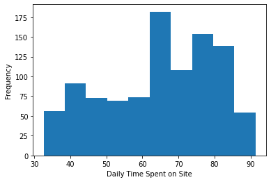

```python
hist = input_data['Daily Time Spent on Site'].plot.hist()
hist.set_xlabel('Daily Time Spent on Site')
```

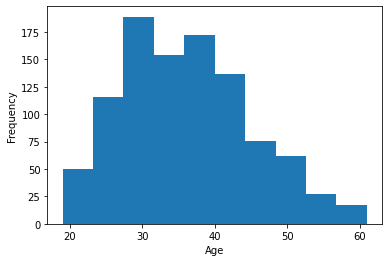

```python
hist = input_data['Age'].plot.hist()
hist.set_xlabel('Age')
```

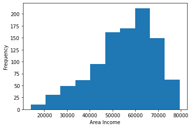

```python
hist = input_data['Area Income'].plot.hist()
hist.set_xlabel('Area Income')
```

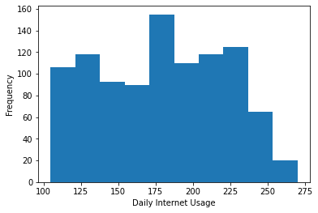

```python
hist = input_data['Daily Internet Usage'].plot.hist()
hist.set_xlabel('Daily Internet Usage')
```

## Part 9

```python
input_data = input_data.drop(columns=['Ad Topic Line', 'City', 'Gender', 'Country', 'Timestamp'])
input_data
```

[output not shown]

1000 rows × 6 columns

Standardization transforms data to have a mean of zero and a standard deviation of 1. This standardization is called a z-score, and data points can be standardized with the following formula: $$z_i = {{x_i - \bar x} \over s}$$

```python
def normalize_column_data(column_name):
    normalized_data[column_name] = (normalized_data[column_name] - normalized_data[column_name].mean()) / normalized_data[column_name].std()

normalized_data = input_data
normalize_column_data('Daily Time Spent on Site')
normalize_column_data('Age')
normalize_column_data('Area Income')
normalize_column_data('Daily Internet Usage')

normalized_data
```

|  | Unnamed: 0 | Daily Time Spent on Site | Age | Area Income | Daily Internet Usage | Clicked on Ad |
| --- | --- | --- | --- | --- | --- | --- |
| 0 | 0 | 2.734741e-01 | -0.116122 | 0.509436 | 1.817578e+00 | 0.0 |
| 1 | 1 | 1.015870e+00 | -0.576377 | 1.002029 | 1.740830e-16 | 0.0 |
| 2 | 2 | 3.076980e-01 | -1.151696 | 0.356770 | 1.351152e+00 | 0.0 |
| 3 | 3 | 6.157131e-01 | -0.806505 | -0.014448 | 1.574722e+00 | 0.0 |
| 4 | 4 | 2.353013e-01 | -0.116122 | 1.408163 | 1.091154e+00 | 0.0 |
| ... | ... | ... | ... | ... | ... | ... |
| 995 | 995 | 5.380512e-01 | -0.691441 | 1.221395 | 6.863941e-01 | 1.0 |
| 996 | 996 | -8.881641e-01 | 1.034517 | 0.952853 | -1.079309e+00 | 1.0 |
| 997 | 997 | -8.664451e-01 | 1.724900 | -0.938101 | -1.413831e+00 | 1.0 |
| 998 | 998 | -6.084495e-01 | -1.957144 | -0.974996 | 1.952066e-01 | 0.0 |
| 999 | 999 | -1.101341e-16 | -1.151696 | -1.872895 | -3.336338e-02 | 1.0 |

1000 rows × 6 columns

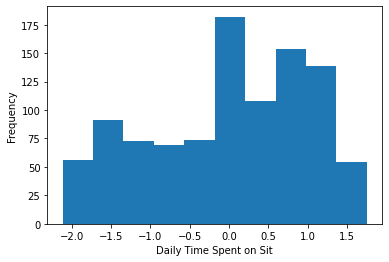

```python
hist = normalized_data['Daily Time Spent on Site'].plot.hist()
hist.set_xlabel('Daily Time Spent on Sit')
```

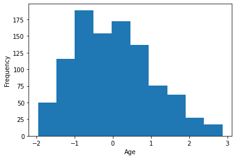

```python
hist = normalized_data['Age'].plot.hist()
hist.set_xlabel('Age')
```

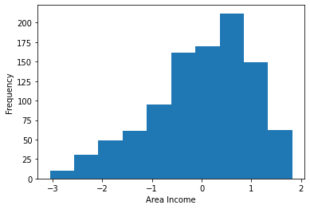

```python
hist = normalized_data['Area Income'].plot.hist()
hist.set_xlabel('Area Income')
```

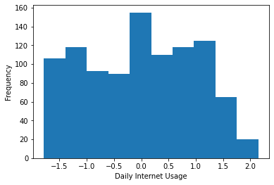

```python
hist = normalized_data['Daily Internet Usage'].plot.hist()
hist.set_xlabel('Daily Internet Usage')
```

## Part 10

```python
mean_data = normalized_data.groupby(['Clicked on Ad']).mean()
mean_data
```

| Clicked on Ad | Unnamed: 0 | Daily Time Spent on Site | Age | Area Income | Daily Internet Usage |
| --- | --- | --- | --- | --- | --- |
| 0.0 | 489.472554 | 0.714104 | -0.493148 | 0.476367 | 0.764216 |
| 1.0 | 504.515738 | -0.691783 | 0.493211 | -0.498632 | -0.753395 |

```python
std_data = normalized_data.groupby(['Clicked on Ad']).std()
std_data
```

| Clicked on Ad | Unnamed: 0 | Daily Time Spent on Site | Age | Area Income | Daily Internet Usage |
| --- | --- | --- | --- | --- | --- |
| 0.0 | 281.453594 | 0.531369 | 0.706315 | 0.670476 | 0.592058 |
| 1.0 | 298.942388 | 0.836161 | 1.019268 | 1.046199 | 0.723959 |

```python
from scipy.stats import norm
import matplotlib.pyplot as plt

click_data = normalized_data[normalized_data['Clicked on Ad'] == 1]
std_click_data = click_data.std()
mean_click_data = click_data.mean()

not_click_data = normalized_data[normalized_data['Clicked on Ad'] == 0]
std_not_click_data = not_click_data.std()
mean_not_click_data = not_click_data.mean()
```

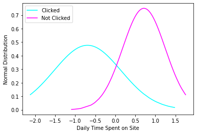

```python
def plt_pdf(column_name, click_data, not_click_data):
    click_data = click_data.sort_values(by = column_name)
    not_click_data = not_click_data.sort_values(by = column_name)

    plt.plot(click_data[column_name], norm.pdf(click_data[column_name], mean_click_data[column_name], std_click_data[column_name]), color='cyan', label="Clicked")
    plt.plot(not_click_data[column_name], norm.pdf(not_click_data[column_name], mean_not_click_data[column_name], std_not_click_data[column_name]), color='magenta', label="Not Clicked")

    plt.ylabel('Normal Distribution')
    plt.xlabel(column_name)
    plt.legend()
    plt.show()

plt_pdf('Daily Time Spent on Site', click_data, not_click_data)
```

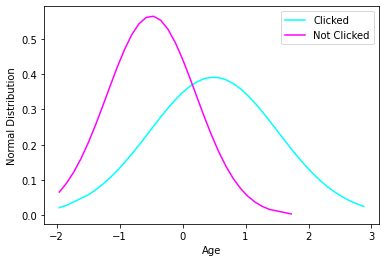

```python
plt_pdf('Age', click_data, not_click_data)
```

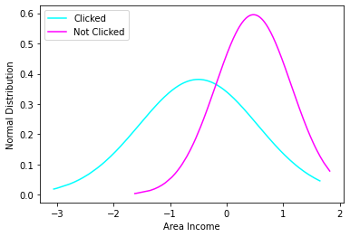

```python
plt_pdf('Area Income', click_data, not_click_data)
```

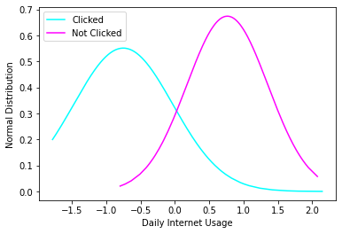

```python
plt_pdf('Daily Internet Usage', click_data, not_click_data)
```

Daily Internet Usage is best variable for guessing clicked variable because clicked and not clicked data are separated from each other. A point in each have a grater probability for belonging to specific category. As we can see from the graph, using this feature, it is more likely to detect whether the user has clicked or not.

## Part 11

For predicting null data, we consider on standard deviation around mean of each group. If data belongs to interval of one group, it gets high chance to belong to that group. other values that are out of these ranges assign to not click by default.

```python
click_range = [mean_click_data['Daily Internet Usage'] - std_click_data['Daily Internet Usage'],
               mean_click_data['Daily Internet Usage'] + std_click_data['Daily Internet Usage']]

not_click_range = [mean_not_click_data['Daily Internet Usage'] - std_not_click_data['Daily Internet Usage'],
               mean_not_click_data['Daily Internet Usage'] + std_not_click_data['Daily Internet Usage']]


final_data = normalized_data[normalized_data['Clicked on Ad'].isnull()].copy()
final_data.loc[(final_data['Daily Internet Usage'] > click_range[0]) &
           (final_data['Daily Internet Usage'] < click_range[1]),'Clicked on Ad'] = 1
final_data.loc[(final_data['Daily Internet Usage'] > not_click_range[0]) &
           (final_data['Daily Internet Usage'] < not_click_range[1]),'Clicked on Ad'] = 0
final_data['Clicked on Ad'].fillna(0, inplace=True)

final_data
```

|  | Unnamed: 0 | Daily Time Spent on Site | Age | Area Income | Daily Internet Usage | Clicked on Ad |
| --- | --- | --- | --- | --- | --- | --- |
| 10 | 10 | -1.129048 | 1.494773 | -0.698304 | -1.374546 | 1.0 |
| 14 | 14 | -1.437721 | -0.346249 | -1.790880 | -0.861692 | 1.0 |
| 15 | 15 | -0.088509 | -1.496888 | -0.210052 | -0.931215 | 1.0 |
| 20 | 20 | 0.817766 | -0.691441 | 0.730719 | 1.064011 | 0.0 |
| 24 | 24 | -1.540393 | 0.574262 | 1.040827 | -0.298362 | 1.0 |
| ... | ... | ... | ... | ... | ... | ... |
| 963 | 963 | -0.266210 | 0.689325 | 1.101465 | 1.602341 | 0.0 |
| 966 | 966 | -1.791149 | 1.839964 | -0.253420 | -0.072649 | 1.0 |
| 967 | 967 | 0.211608 | -1.266760 | 0.995775 | 0.204016 | 0.0 |
| 977 | 977 | -0.646622 | -0.576377 | -0.231089 | -1.508831 | 0.0 |
| 992 | 992 | 0.287953 | 0.459198 | 0.834448 | -1.336451 | 1.0 |

168 rows × 6 columns

```python
final_data['Clicked on Ad'].to_csv('out.csv')
```